# Analysis of the World dataset

## Install the packages

```r
# r setup, eval=FALSE
install.packages('tidyverse')
install.packages('plotrix')
install.packages('ggplot2')
install.packages("dplyr")
```

## Load the Packages

```r
library(tidyverse)  # package for data analysis in R
```

```r
library(plotrix)  # contains various functions for plotting
```

## 1. Load Data

Load the world.csv dataset and store it as an object “world.data”.

```r
world.data <- read_csv('world csv new.csv')
# view first few rows
head(world.data)
```

```
## # A tibble: 6 × 62
##   country colony confi…¹ decen…² dem_o…³ dem_o…⁴ democ…⁵ distr…⁶ durable effec…⁷
##   <chr>   <chr>    <dbl>   <dbl>   <dbl> <chr>   <chr>   <chr>     <dbl>   <dbl>
## 1 Afghan… UK        NA     NA       10.5 10%     No      single…       4    13.7
## 2 Albania Sovie…    49.3    0.74    63   Approx… Yes     <NA>          3    35.5
## 3 Algeria France    52.1   NA       40.8 Approx… No      6 or m…       5    32.6
## 4 Andorra Spain     NA     NA      100   100%    Yes     <NA>         NA    78.7
## 5 Angola  Portu…    NA     NA       40.8 Approx… No      <NA>          3    19.1
## 6 Antigu… UK        NA     NA       87.5 Approx… Yes     single…      NA    59.8
## # … with 52 more variables: enpp_3 <chr>, eu <chr>, fhrate04_rev <chr>,
## #   fhrate08_rev <dbl>, frac_eth <dbl>, frac_eth3 <chr>, free_business <dbl>,
## #   free_corrupt <dbl>, free_finance <dbl>, free_fiscal <dbl>,
## #   free_govspend <dbl>, free_invest <dbl>, free_labor <dbl>,
## #   free_monetary <dbl>, free_overall <dbl>, free_property <dbl>,
## #   free_trade <dbl>, gdp08 <dbl>, gdp_10_thou <dbl>, gdp_cap2 <chr>,
## #   gdp_cap3 <chr>, gdppcap08 <dbl>, gender_equal3 <chr>, gini04 <dbl>, …
```

## 2. Create frequency table of the OECD variable

```r
# create frequency table with the table() function
freq_table <- table(world.data$oecd)
# calculate the percentages
percentage <- freq_table / sum(freq_table) * 100
# convert the frequency table to a dataframe
ft.oecd <- as.data.frame(freq_table)
# add the Percentage column to the dataframe
ft.oecd$Percentage <- percentage
# rename the first column to "OECD Member?"
names(ft.oecd)[1] <- "OECD Member?"
ft.oecd
```

```
##        OECD Member? Freq Percentage
## 1        Not member  161   84.29319
## 2 OECD Member state   30   15.70681
```

## 3. Frequency Table Observation

- 30 countries are OECD members.
- 161 countries are not OECD members.
- 15.7% of the countries are OECD members.
- 84.3% of the countries are not OECD members.

## 4. Barchart of the OECD variable

Use the ggplot library in tidyverse to create a bar chart

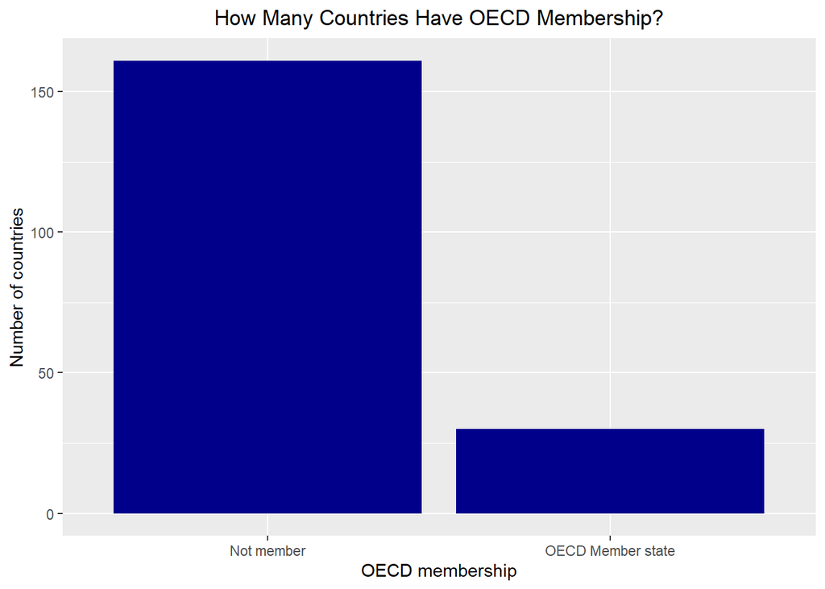

```r
ggplot(data=world.data) +
  geom_bar(mapping=aes(x=oecd), fill='darkblue') +
  # Add title to the plot
  labs(title='How Many Countries Have OECD Membership?') +
  # centralize the title
  theme(plot.title = ggplot2::element_text(hjust = 0.5)) +
  # Add xlabel to the x-axis
  xlab('OECD membership') +
  # Add ylabel to the y-axis
  ylab('Number of countries')
```

## 5. OECD member states and non-democratic states

#### OECD member states

- Australia
- Austria
- Belgium

#### Non-democratic states

- Afghanistan
- Algeria
- Angola

## 6. Statistical Description of the `gdp_10_thou` variable.

```r
# print summary statistic of the `gdp_10_thou` variable
summary(world.data$gdp_10_thou)
```

```
##    Min. 1st Qu.  Median    Mean 3rd Qu.    Max.    NA's
##  0.0090  0.0503  0.1897  0.6018  0.6320  4.7354      14
```

```r
# check the standard deviation & ignore missing values
sd(world.data$gdp_10_thou, na.rm=TRUE)
```

```
## [1] 0.9433982
```

- The minimum value is 0.0090
- The maximum value is 4.7354
- The median value is 0.1897
- The mean value is 0.6018
- The 1st quartile value is 0.0503
- The 3rd quartile value is 0.6320
- The standard deviation is 0.9433982

## 7. Left or Right Skewed?

Since the mean is greater than the median ($6,018 > $ 1,897), the data is positively skewed (skewed to the right).

## 8. Histogram of the per capita GDP variable

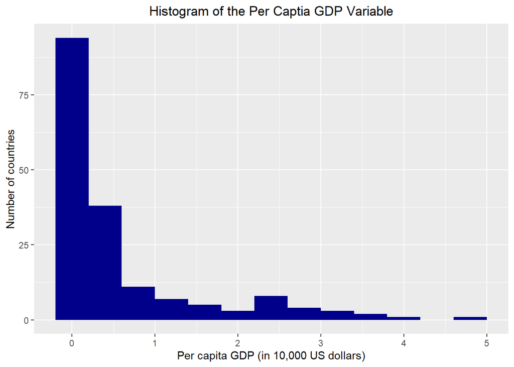

```r
# r setup, warning=FALSE
ggplot(data=world.data) +
  # Plot histogram
  geom_histogram(mapping=ggplot2::aes(x=gdp_10_thou), fill='darkblue', binwidth=0.4) +
  labs(title='Histogram of the Per Captia GDP Variable') +
  # centralize the title
  theme(plot.title=ggplot2::element_text(hjust = 0.5)) +
  # Add xlabel to the x-axis
  xlab('Per capita GDP (in 10,000 US dollars)') +
  # Add ylabel to the y-axis
  ylab('Number of countries')
```

## 9. The two countries with per capita GDP over $40,000

```r
# filter dataframe to view countries whose GDP is over $40,000
world.data %>% filter(gdp_10_thou>4)
```

```
## # A tibble: 2 × 62
##   country colony confi…¹ decen…² dem_o…³ dem_o…⁴ democ…⁵ distr…⁶ durable effec…⁷
##   <chr>   <chr>    <dbl>   <dbl>   <dbl> <chr>   <chr>   <chr>     <dbl>   <dbl>
## 1 Luxemb… Nethe…    NA      1.16     100 100%    Yes     6 or m…      NA    96.9
## 2 Norway  none      66.5    1.79     100 100%    Yes     6 or m…      54    90.1
## # … with 52 more variables: enpp_3 <chr>, eu <chr>, fhrate04_rev <chr>,
## #   fhrate08_rev <dbl>, frac_eth <dbl>, frac_eth3 <chr>, free_business <dbl>,
## #   free_corrupt <dbl>, free_finance <dbl>, free_fiscal <dbl>,
## #   free_govspend <dbl>, free_invest <dbl>, free_labor <dbl>,
## #   free_monetary <dbl>, free_overall <dbl>, free_property <dbl>,
## #   free_trade <dbl>, gdp08 <dbl>, gdp_10_thou <dbl>, gdp_cap2 <chr>,
## #   gdp_cap3 <chr>, gdppcap08 <dbl>, gender_equal3 <chr>, gini04 <dbl>, …
```

- The two countries with per capita GDP over $40,000 are Luxembourg and Norway.

## 10. Calculate the standard error of the per capita GDP variable.

```r
# r setup, warning=FALSE
# use the plotrix package to calculate the standard error
print(std.error(world.data$gdp_10_thou))
```

```
## [1] 0.07091015
```

```r
# or manually calculate it with the formular: standard deviation/square root of the sample size
# sample size is the total number of rows minus the number of missing values in the gdp_10thou variable

standard_error <- sd(world.data$gdp_10_thou, na.rm=TRUE)/sqrt(nrow(world.data)-sum(is.na(world.data$gdp_10_thou)))
print(standard_error)
```

```
## [1] 0.07091015
```

The standard error is 0.07091015

## 11. Calculate the 95% Confidence Interval

Formula: Confidence Interval = sample mean +- margin of error margin of error = z* x standard error

For 95% confidence interval, z* = 1.96

Therefore, 95% confidence interval = sample mean +- 1.96 * stardard error

```r
# calculate the margin of error using the standard error
margin_of_error <- 1.96*standard_error
# calculate the mean of the gdp_10_thou variable
sample_mean <- mean(world.data$gdp_10_thou, na.rm=TRUE)

# Print out the results
cat("The margin of error is", margin_of_error, '\n')
```

```
## The margin of error is 0.1389839
```

```r
cat("The sample mean is", sample_mean, '\n')
```

```
## The sample mean is 0.6018186
```

```r
# Calculate the confidence interval range
confidence_interval_upper <- sample_mean + margin_of_error
confidence_interval_lower <- sample_mean - margin_of_error

# Print out the results
cat("The upper confidence interval is", confidence_interval_upper, '\n')
```

```
## The upper confidence interval is 0.7408025
```

```r
cat("The lower confidence interval is", confidence_interval_lower, '\n\n')
```

```
## The lower confidence interval is 0.4628347
```

```r
cat("The 95% confidence interval ranges from", confidence_interval_lower, '-', confidence_interval_upper)
```

```
## The 95% confidence interval ranges from 0.4628347 - 0.7408025
```

## 12. Histograms of per capita GDP variable. One for democracies and the other for non-democracies.

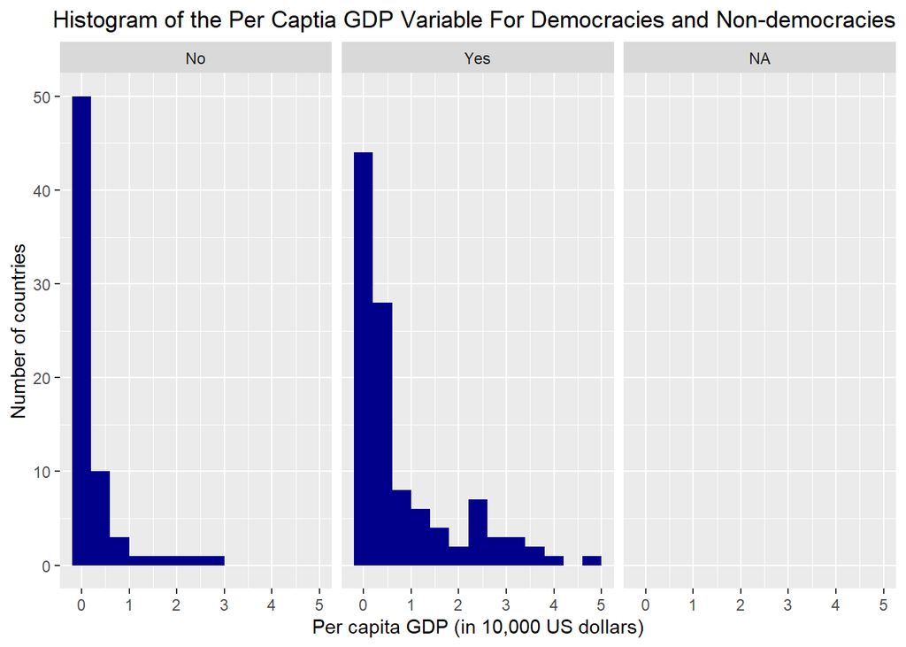

```r
# r setup, warning=FALSE
ggplot2::ggplot(data=world.data) +
  ggplot2::geom_histogram(mapping=ggplot2::aes(x=gdp_10_thou), fill='darkblue', binwidth=0.4) +
  ggplot2::labs(title='Histogram of the Per Captia GDP Variable For Democracies and Non-democracies ') +
  # centralize the title
  ggplot2::theme(plot.title = element_text(hjust = 0.5)) +
  ggplot2::xlab('Per capita GDP (in 10,000 US dollars)') +
  ggplot2::ylab('Number of countries') +
  # create a facet_wrap of the democ_regime variable
  ggplot2::facet_wrap(~democ_regime)
```

## 13. Fix Histogram

I have to get rid of the missing values in the democ_regime variable represented by ‘NA’. Then create a new variable called ‘dem.dum’ based on the variable ‘democ_regime’. It will be more descriptive than the ‘democ_regime’ variable.

```r
# remove NA values in the democ_regime variable
dem.gdp <- world.data %>% drop_na('democ_regime')
# create a new column called dem.dum in the dem.gdp dataframe
# the value will be 'Democracy' if the value in the democ_regime variable is 'Yes'
# otherwise it will be 'Autocracy'
dem.gdp <- transform(dem.gdp, dem.dum=ifelse(democ_regime=='Yes', 'Democracy', 'Autocracy'))
# view a few rows of the new dataframe
head(dem.gdp)
```

```
##             country       colony confidence decentralization dem_other
## 1       Afghanistan           UK         NA               NA      10.5
## 2           Albania Soviet Union   49.33593             0.74      63.0
## 3           Algeria       France   52.05573               NA      40.8
## 4           Andorra        Spain         NA               NA     100.0
## 5            Angola     Portugal         NA               NA      40.8
## 6 Antigua & Barbuda           UK         NA               NA      87.5
##   dem_other5 democ_regime    district_size3 durable effectiveness      enpp_3
## 1        10%           No     single member       4      13.71158        <NA>
## 2 Approx 60%          Yes              <NA>       3      35.46099 1-3 parties
## 3 Approx 40%           No 6 or more members       5      32.62411        <NA>
## 4       100%          Yes              <NA>      NA      78.72340        <NA>
## 5 Approx 40%           No              <NA>       3      19.14894        <NA>
## 6 Approx 90%          Yes     single member      NA      59.81088 1-3 parties
##           eu fhrate04_rev fhrate08_rev frac_eth frac_eth3 free_business
```

[output cut: 55 more lines]

Now plot the histogram with this cleaned dataframe.

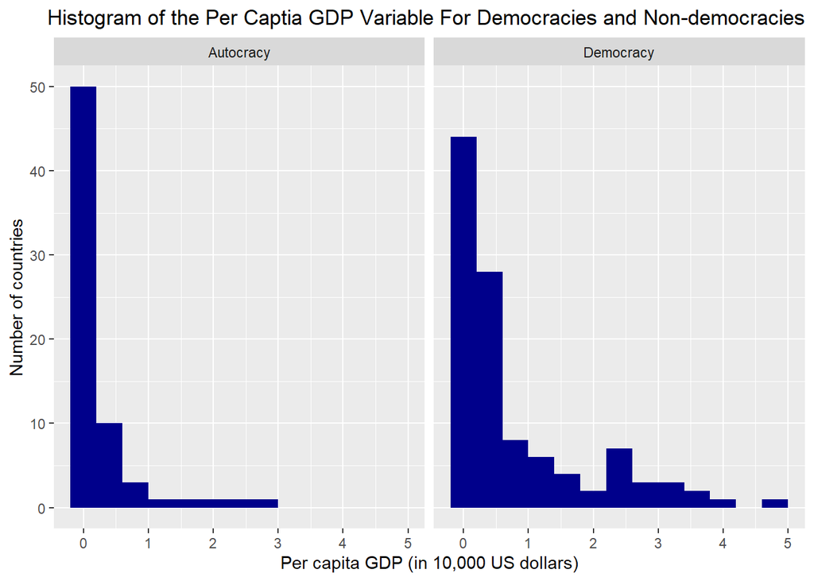

```r
# r setup, warning=FALSE
ggplot(data=dem.gdp) +
  geom_histogram(mapping=aes(x=gdp_10_thou), fill='darkblue', binwidth=0.4) +
  labs(title='Histogram of the Per Captia GDP Variable For Democracies and Non-democracies ') +
  # centralize the title
  theme(plot.title = element_text(hjust=0.5)) +
  xlab('Per capita GDP (in 10,000 US dollars)') +
  ylab('Number of countries') +
  facet_wrap(~dem.dum)
```

## 14. Mean of per capita GDP for democracies & the 95 % confidence interval

```r
# filter data to get democratic countries only
democracies <- dem.gdp %>% filter(dem.dum=='Democracy')
head(democracies)
```

```
##             country       colony confidence decentralization dem_other
## 1           Albania Soviet Union  49.335926             0.74      63.0
## 2           Andorra        Spain         NA               NA     100.0
## 3 Antigua & Barbuda           UK         NA               NA      87.5
## 4         Argentina        Spain   7.299325             2.40      87.5
## 5           Armenia Soviet Union  27.132735               NA      63.0
## 6         Australia           UK  46.838886             1.74      58.3
##   dem_other5 democ_regime    district_size3 durable effectiveness       enpp_3
## 1 Approx 60%          Yes              <NA>       3      35.46099  1-3 parties
## 2       100%          Yes              <NA>      NA      78.72340         <NA>
## 3 Approx 90%          Yes     single member      NA      59.81088  1-3 parties
## 4 Approx 90%          Yes 6 or more members      17      34.98818  1-3 parties
## 5 Approx 60%          Yes              <NA>       2      36.64303 6-11 parties
## 6 Approx 60%          Yes     single member      99      90.07092  1-3 parties
##           eu fhrate04_rev fhrate08_rev frac_eth frac_eth3 free_business
```

[output cut: 55 more lines]

```r
# create a function to calculate the mean and the 95% confidence interval
# the function will take in a dataframe as an argument
mean_and_95_CI <- function(dataframe) {
  # calculate the standard error
  standard_error <- std.error(dataframe$gdp_10_thou)
  # calculate the margin of error
  margin_of_error <- 1.96 * standard_error
  # calculate the sample mean
  sample_mean <- mean(dataframe$gdp_10_thou, na.rm=TRUE)

  # Display results
  cat("The standard_error is", standard_error, '\n')
  cat("The margin of error is", margin_of_error, '\n')
  cat("The sample mean is", sample_mean, '\n')

  # Calculate the confidence interval range
  confidence_interval_upper <- sample_mean + margin_of_error
  confidence_interval_lower <- sample_mean - margin_of_error

  # Print out the result
  cat("The upper confidence interval is", confidence_interval_upper, '\n')
  cat("The lower confidence interval is", confidence_interval_lower, '\n\n')
  cat("The 95% confidence interval ranges from", confidence_interval_lower, '-', confidence_interval_upper)
}

# invoke function for democratic countries
# by passing the democracies dataframe
mean_and_95_CI(democracies)
```

```
## The standard_error is 0.103553
## The margin of error is 0.2029639
## The sample mean is 0.8013927
## The upper confidence interval is 1.004357
## The lower confidence interval is 0.5984288
##
## The 95% confidence interval ranges from 0.5984288 - 1.004357
```

## 15. Mean of per capita GDP & the 95 % Confidence Interval For Autocracies

```r
# filter data to get autocratic countries only
autocracies <- dem.gdp %>% filter(dem.dum=='Autocracy')
head(autocracies)
```

```
##       country       colony confidence decentralization dem_other dem_other5
## 1 Afghanistan           UK         NA               NA      10.5        10%
## 2     Algeria       France   52.05573               NA      40.8 Approx 40%
## 3      Angola     Portugal         NA               NA      40.8 Approx 40%
## 4  Azerbaijan Soviet Union   54.16848             1.19      63.0 Approx 60%
## 5     Bahrain           UK         NA               NA      10.5        10%
## 6     Belarus Soviet Union   15.64570             1.24      63.0 Approx 60%
##   democ_regime    district_size3 durable effectiveness enpp_3         eu
## 1           No     single member       4      13.71158   <NA> Not member
## 2           No 6 or more members       5      32.62411   <NA> Not member
## 3           No              <NA>       3      19.14894   <NA> Not member
## 4           No              <NA>       5      23.87707   <NA> Not member
## 5           No     single member      25      65.01182   <NA> Not member
## 6           No     single member       4      22.22222   <NA> Not member
##   fhrate04_rev fhrate08_rev frac_eth frac_eth3 free_business free_corrupt
```

[output cut: 55 more lines]

```r
# invoke function for autocratic countries
# by passing the autocracies dataframe
mean_and_95_CI(autocracies)
```

```
## The standard_error is 0.06475749
## The margin of error is 0.1269247
## The sample mean is 0.2819132
## The upper confidence interval is 0.4088379
## The lower confidence interval is 0.1549886
##
## The 95% confidence interval ranges from 0.1549886 - 0.4088379
```

- The mean of per capita GDP for democracies is 0.8013927.
- The 95% confidence interval for democracies ranges from 0.5984288 - 1.004357.
- The mean of per capita GDP for autocracies (non-democracies) is 0.2819132.
- The 95% confidence interval for autocracies ranges from 0.1549886 - 0.4088379.